# Constructing Triangles from Claims Transactions

Author

Mick Cooney mcooney@describedata.com

Published

August 21, 2024

# 1 Load Claim Transactions Data

First we load up the transactional data for the claims

```r
claim_transactions_tbl <- read_rds("data/claims_transactions_tbl.rds") |>
  filter(transaction_date < as.Date("2017-01-01"))

claim_transactions_tbl |> glimpse()
```

```
Rows: 436,908
Columns: 8
$ country_code     <chr> "AUT", "AUT", "AUT", "AUT", "AUT", "AUT", "AUT", "AUT…
$ year             <int> 2000, 2000, 2000, 2000, 2000, 2000, 2000, 2000, 2000,…
$ claim_id         <chr> "AUT200001CL0001", "AUT200001CL0001", "AUT200001CL000…
$ incident_date    <date> 2000-01-03, 2000-01-03, 2000-01-05, 2000-01-05, 2000…
$ report_date      <date> 2000-01-20, 2000-01-20, 2000-01-13, 2000-01-13, 2000…
$ transaction_date <date> 2001-10-06, 2007-08-31, 2000-03-12, 2001-05-30, 2005…
$ claim_type       <chr> "PD", "PD", "PD", "PD", "PD", "PD", "PD", "PD", "PD",…
$ amount           <dbl> 501.87, 1195.22, 80.06, 406.39, 644.63, 386.06, 292.0…
```

We want to show all these transactions in a formatted table to give us a sense for what this data looks like.

```r
claim_transactions_tbl |>
  head(100) |>
  knitr::kable()
```

| country_code | year | claim_id | incident_date | report_date | transaction_date | claim_type | amount |
| --- | --- | --- | --- | --- | --- | --- | --- |
| AUT | 2000 | AUT200001CL0001 | 2000-01-03 | 2000-01-20 | 2001-10-06 | PD | 501.87 |
| AUT | 2000 | AUT200001CL0001 | 2000-01-03 | 2000-01-20 | 2007-08-31 | PD | 1195.22 |
| AUT | 2000 | AUT200001CL0002 | 2000-01-05 | 2000-01-13 | 2000-03-12 | PD | 80.06 |
| AUT | 2000 | AUT200001CL0002 | 2000-01-05 | 2000-01-13 | 2001-05-30 | PD | 406.39 |
| AUT | 2000 | AUT200001CL0002 | 2000-01-05 | 2000-01-13 | 2005-04-18 | PD | 644.63 |
| AUT | 2000 | AUT200001CL0003 | 2000-01-06 | 2000-01-15 | 2001-02-27 | PD | 386.06 |
| AUT | 2000 | AUT200001CL0003 | 2000-01-06 | 2000-01-15 | 2001-08-01 | PD | 292.00 |
| AUT | 2000 | AUT200001CL0003 | 2000-01-06 | 2000-01-15 | 2001-10-09 | PD | 483.37 |
| AUT | 2000 | AUT200001CL0003 | 2000-01-06 | 2000-01-15 | 2002-01-24 | PD | 251.77 |
| AUT | 2000 | AUT200001CL0003 | 2000-01-06 | 2000-01-15 | 2002-05-09 | PD | 324.77 |
| AUT | 2000 | AUT200001CL0003 | 2000-01-06 | 2000-01-15 | 2002-11-26 | PD | 410.98 |
| AUT | 2000 | AUT200001CL0003 | 2000-01-06 | 2000-01-15 | 2004-09-06 | PD | 583.46 |
| AUT | 2000 | AUT200001CL0004 | 2000-01-06 | 2000-01-27 | 2002-10-26 | PD | 1885.54 |
| AUT | 2000 | AUT200001CL0004 | 2000-01-06 | 2000-01-27 | 2003-09-15 | PD | 2350.32 |
| AUT | 2000 | AUT200001CL0004 | 2000-01-06 | 2000-01-27 | 2004-02-28 | PD | 2744.87 |
| AUT | 2000 | AUT200001CL0004 | 2000-01-06 | 2000-01-27 | 2005-09-10 | PD | 2328.95 |
| AUT | 2000 | AUT200001CL0005 | 2000-01-06 | 2000-01-21 | 2000-06-18 | PD | 46.84 |
| AUT | 2000 | AUT200001CL0005 | 2000-01-06 | 2000-01-21 | 2001-07-01 | PD | 170.21 |
| AUT | 2000 | AUT200001CL0005 | 2000-01-06 | 2000-01-21 | 2001-08-03 | PD | 221.12 |
| AUT | 2000 | AUT200001CL0005 | 2000-01-06 | 2000-01-21 | 2002-07-22 | PD | 360.75 |
| AUT | 2000 | AUT200001CL0005 | 2000-01-06 | 2000-01-21 | 2004-09-11 | PD | 442.09 |
| AUT | 2000 | AUT200001CL0006 | 2000-01-07 | 2000-01-09 | 2000-07-06 | PD | 1418.02 |
| AUT | 2000 | AUT200001CL0006 | 2000-01-07 | 2000-01-09 | 2001-04-01 | PD | 2817.06 |
| AUT | 2000 | AUT200001CL0006 | 2000-01-07 | 2000-01-09 | 2002-06-25 | PD | 2140.19 |
| AUT | 2000 | AUT200001CL0006 | 2000-01-07 | 2000-01-09 | 2003-05-05 | PD | 2684.27 |
| AUT | 2000 | AUT200001CL0006 | 2000-01-07 | 2000-01-09 | 2005-04-06 | PD | 3174.21 |
| AUT | 2000 | AUT200001CL0007 | 2000-01-08 | 2000-02-04 | 2002-02-06 | PD | 807.76 |
| AUT | 2000 | AUT200001CL0007 | 2000-01-08 | 2000-02-04 | 2004-05-25 | PD | 1261.13 |
| AUT | 2000 | AUT200001CL0008 | 2000-01-09 | 2000-02-27 | 2000-05-07 | PD | 360.18 |
| AUT | 2000 | AUT200001CL0008 | 2000-01-09 | 2000-02-27 | 2001-03-01 | PD | 1003.18 |

[output cut: 70 more lines]

# 2 Constructing the Triangles

Our transaction data tells us when various ‘movements’ on a claim occur, in our simplified case, we will simply treat these as paid amounts and build a triangle on these.

To do this effectively, we need to create our ‘development periods’ which are regular periods of time over which we want to build our triangles. For this exercise, we use yearly periods (but it could also be quarters or months or some other unit of time).

To do this, we need to determine how many periods of time we want to expand across, which in this case will be the all the years from the earliest year up to the point of observation of the data, which for the purposes of this data is the start of 2017.

```r
min_year <- claim_transactions_tbl |>
  pull(year) |>
  min()

max_year <- claim_transactions_tbl |>
  pull(year) |>
  max()

dev_periods_tbl <- tibble(
  dev_period = 1:(max_year - min_year + 1)
  )


claim_development_periods_tbl <- claim_transactions_tbl |>
  select(country_code, year, claim_id, claim_type) |>
  distinct() |>
  crossing(dev_periods_tbl)

claim_transactions_periods_tbl <- claim_transactions_tbl |>
  mutate(
    dev_period = year(transaction_date) - year + 1
    ) |>
  select(country_code, year, claim_id, claim_type, dev_period, amount)
```

We now want to combine all this up into individual development period for each claim.

```r
claim_full_development_tbl <- claim_development_periods_tbl |>
  left_join(
    claim_transactions_periods_tbl,
    by = c("country_code", "year", "claim_id", "claim_type", "dev_period"),
    relationship = "many-to-many"
    ) |>
  replace_na(
    list(amount = 0)
    ) |>
  filter(year + dev_period < 2018)

claim_full_development_tbl |> glimpse()
```

```
Rows: 1,326,261
Columns: 6
$ country_code <chr> "AUT", "AUT", "AUT", "AUT", "AUT", "AUT", "AUT", "AUT", "…
$ year         <int> 2000, 2000, 2000, 2000, 2000, 2000, 2000, 2000, 2000, 200…
$ claim_id     <chr> "AUT200001CL0001", "AUT200001CL0001", "AUT200001CL0001", …
$ claim_type   <chr> "BI", "BI", "BI", "BI", "BI", "BI", "BI", "BI", "BI", "BI…
$ dev_period   <dbl> 1, 2, 3, 3, 4, 5, 6, 7, 8, 9, 10, 11, 12, 13, 14, 15, 16,…
$ amount       <dbl> 0.00, 0.00, 1213.81, 1434.26, 1596.15, 0.00, 0.00, 0.00, …
```

We now want to add up the various movements within a development period so we end up with just a single entry for each claim within a development period.

```r
claim_development_increments_tbl <- claim_full_development_tbl |>
  count(
    country_code, year, claim_id, claim_type, dev_period,
    wt   = amount,
    name = "period_increment"
    )

claim_development_increments_tbl |> glimpse()
```

```
Rows: 1,213,976
Columns: 6
$ country_code     <chr> "AUT", "AUT", "AUT", "AUT", "AUT", "AUT", "AUT", "AUT…
$ year             <int> 2000, 2000, 2000, 2000, 2000, 2000, 2000, 2000, 2000,…
$ claim_id         <chr> "AUT200001CL0001", "AUT200001CL0001", "AUT200001CL000…
$ claim_type       <chr> "BI", "BI", "BI", "BI", "BI", "BI", "BI", "BI", "BI",…
$ dev_period       <dbl> 1, 2, 3, 4, 5, 6, 7, 8, 9, 10, 11, 12, 13, 14, 15, 16…
$ period_increment <dbl> 0.00, 0.00, 2648.07, 1596.15, 0.00, 0.00, 0.00, 0.00,…
```

We now want to aggregate for each underwriting year into each development period across all the claims. We then calculate the cumulative amounts.

```r
claim_development_data_tbl <- claim_development_increments_tbl |>
  count(
    country_code, year, claim_type, dev_period,
    wt   = period_increment,
    name = "reserving_increment"
    ) |>
  arrange(country_code, year, claim_type, dev_period) |>
  mutate(
    reserving_cumulative = cumsum(reserving_increment),

    .by = c(country_code, year, claim_type)
    )
```

We now want to visualise one of these claim triangles such as the BI claims for Austria (AUT)

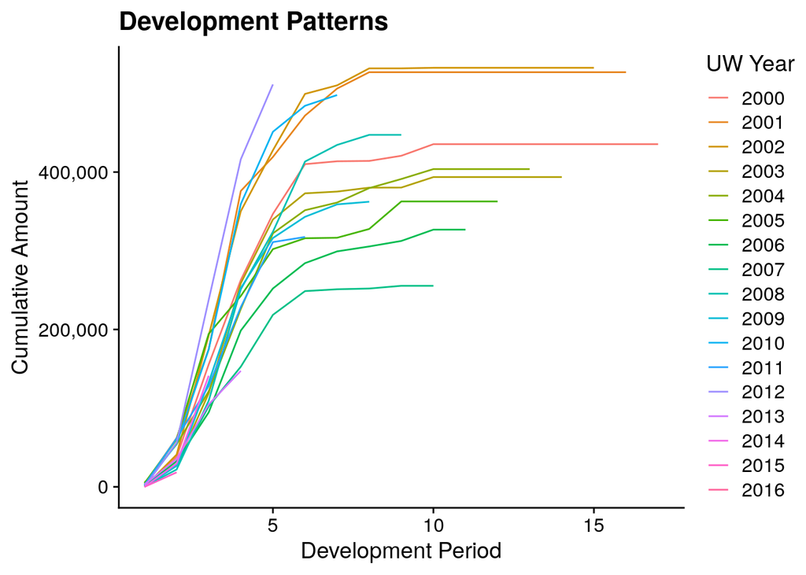

```r
plot_tbl <- claim_development_data_tbl |>
  filter(
    country_code == "AUT",
    claim_type   == "BI"
    ) |>
  mutate(
    year = as.character(year)
    )


ggplot(plot_tbl) +
  geom_line(aes(x = dev_period, y = reserving_cumulative, colour = year)) +
  scale_y_continuous(labels = label_comma()) +
  labs(
    x = "Development Period",
    y = "Cumulative Amount",
    colour = "UW Year",
    title  = "Development Patterns"
    )
```

# 3 Using Triangle Construction Function

We now have created a function that takes a set of transactions and converts it into the ‘long’ form of the triangles on a claim-by-claim basis (as this is a format commonly used for actuarial reserving software such as ResQ).

This data is then easily reshaped into more traditional actuarial triangles.

To start, we need a single set of transactions to transform, so for this data we will choose Austrian bodily-injury claims (`country_code` of AUT and `claim_type` is BI).

```r
use_tnxdata_tbl <- claim_transactions_tbl |>
  filter(
    country_code == "AUT",
    claim_type   == "BI"
    )

use_tnxdata_tbl |> glimpse()
```

```
Rows: 2,574
Columns: 8
$ country_code     <chr> "AUT", "AUT", "AUT", "AUT", "AUT", "AUT", "AUT", "AUT…
$ year             <int> 2000, 2000, 2000, 2000, 2000, 2000, 2000, 2000, 2000,…
$ claim_id         <chr> "AUT200001CL0001", "AUT200001CL0001", "AUT200001CL000…
$ incident_date    <date> 2000-01-03, 2000-01-03, 2000-01-03, 2000-01-15, 2000…
$ report_date      <date> 2000-01-20, 2000-01-20, 2000-01-20, 2000-01-29, 2000…
$ transaction_date <date> 2002-01-27, 2002-12-26, 2003-06-26, 2001-01-06, 2001…
$ claim_type       <chr> "BI", "BI", "BI", "BI", "BI", "BI", "BI", "BI", "BI",…
$ amount           <dbl> 1213.81, 1434.26, 1596.15, 7.29, 25.60, 25.33, 33.81,…
```

We have create a function called `construct_claim_triangles()` that allows us to select the origin date, development period and so on.

```r
triangle_incr_annual_tbl <- use_tnxdata_tbl |>
  construct_claim_triangles(
    dev_period = "ann",
    agg_type   = "incr",
    as_at      = as.Date("2016-12-31")
    )

triangle_incr_annual_tbl |> glimpse()
```

```
Rows: 1,863
Columns: 5
$ origin_year <int> 2000, 2000, 2000, 2000, 2000, 2000, 2000, 2000, 2000, 2000…
$ claim_id    <chr> "AUT200001CL0001", "AUT200001CL0001", "AUT200001CL0010", "…
$ dev_period  <int> 2, 3, 1, 2, 8, 1, 3, 4, 0, 1, 2, 4, 1, 2, 1, 4, 1, 2, 8, 1…
$ agg_type    <chr> "incr", "incr", "incr", "incr", "incr", "incr", "incr", "i…
$ amount      <dbl> 2648.07, 1596.15, 32.89, 25.33, 33.81, 72.43, 135.55, 124.…
```

We can also construct this triangle using quarterly development periods.

```r
triangle_incr_quarter_tbl <- use_tnxdata_tbl |>
  construct_claim_triangles(
    dev_period = "qtr",
    agg_type   = "incr",
    as_at      = as.Date("2016-12-31")
    )

triangle_incr_quarter_tbl |> glimpse()
```

```
Rows: 2,345
Columns: 5
$ origin_year <int> 2000, 2000, 2000, 2000, 2000, 2000, 2000, 2000, 2000, 2000…
$ claim_id    <chr> "AUT200001CL0001", "AUT200001CL0001", "AUT200001CL0001", "…
$ dev_period  <int> 5, 8, 10, 1, 3, 6, 32, 2, 11, 13, 0, 1, 5, 15, 1, 3, 6, 3,…
$ agg_type    <chr> "incr", "incr", "incr", "incr", "incr", "incr", "incr", "i…
$ amount      <dbl> 1213.81, 1434.26, 1596.15, 7.29, 25.60, 25.33, 33.81, 72.4…
```